# 상위 네 팀의 개별 스텟 간 상관분석

상위 네 팀의 개별 경기 스텟 간 상관을 분석하여 전체 경기와의 차이를 확인하고, 팀끼리의 차이 또한 발견함에 목적이 있다.

## 준비

- 패키지 설치
- 라이브러리 부착
- 데이터 불러오기 - json

```r
# 패키지 설치
# install.packages('jsonlite') : json파일을 읽기
# install.packages("PerformanceAnalytics") : 상관분석 시각화
# install.packages("corrplot") : 상관분석 시각화
```

```r
# 라이브러리 부착
library(jsonlite)
library(PerformanceAnalytics)
library(corrplot)
```

```r
# 최근 다섯 시즌 상위 네 팀의 경기 데이터를 불러오기(리버풀, 첼시, 맨시티, 토트넘)
Liverpool = fromJSON('Liverpool.json')
Chelsea = fromJSON('Chelsea.json')
Mancity = fromJSON('Manchester_City.json')
Tottenham = fromJSON('Tottenham_Hotspur.json')
```

## 데이터 프레임 생성

- 데이터 프레임 생성
- 변수명 변경
- 불필요한 변수 제거

```r
# 데이터 프레임 생성
Liverpool_df = data.frame(Liverpool)
Chelsea_df = data.frame(Chelsea)
Mancity_df = data.frame(Mancity)
Tottenham_df = data.frame(Tottenham)
```

```r
# 변수명 확인
colnames(Liverpool_df)
```

1. 'list.Team'

2. 'list.Matchyear'

3. 'list.Matchday'

4. 'list.WinorLose'

5. 'list.Formation'

6. 'list.Possession'

7. 'list.Shots'

8. 'list.Shots_on_Target'

9. 'list.Touches'

10. 'list.Passes'

11. 'list.Tackles'

12. 'list.Clearances'

13. 'list.Corners'

14. 'list.Offsides'

15. 'list.Yellow_cards'

16. 'list.Red_cards'

17. 'list.Fouls_conceded'

18. 'list.num'

```r
# 새로운 변수명 생성
col_list  <- c('Team','Matchyear','Matchday','WinorLose','Formation','Possession','Shots','Shots_on_target','Touches','Passes','Tackles','Clearances','Corners','Offsides','Yellow_cards','Red_cards','Foul_conceded','num')
```

```r
# 새로운 변수명 부여
colnames(Liverpool_df) <- col_list
colnames(Chelsea_df) <- col_list
colnames(Mancity_df) <- col_list
colnames(Tottenham_df) <- col_list
```

```r
# 변수명 확인
colnames(Liverpool_df)
```

1. 'Team'

2. 'Matchyear'

3. 'Matchday'

4. 'WinorLose'

5. 'Formation'

6. 'Possession'

7. 'Shots'

8. 'Shots_on_target'

9. 'Touches'

10. 'Passes'

11. 'Tackles'

12. 'Clearances'

13. 'Corners'

14. 'Offsides'

15. 'Yellow_cards'

16. 'Red_cards'

17. 'Foul_conceded'

18. 'num'

```r
# 불필요한 변수 제거 : 팀명, 경기년도, 경기일, 승패여부, 포메이션, 경기식별번호
Liverpool_df  <- subset(Liverpool_df , select = c(-Team,-Matchyear,-Matchday,-WinorLose,-Formation,-num))
Chelsea_df  <- subset(Chelsea_df , select = c(-Team,-Matchyear,-Matchday,-WinorLose,-Formation,-num))
Mancity_df  <- subset(Mancity_df , select = c(-Team,-Matchyear,-Matchday,-WinorLose,-Formation,-num))
Tottenham_df  <- subset(Tottenham_df , select = c(-Team,-Matchyear,-Matchday,-WinorLose,-Formation,-num))
```

```r
# 불필요 변수 제거 확인
head(Liverpool_df)
```

| Possession | Shots | Shots_on_target | Touches | Passes | Tackles | Clearances | Corners | Offsides | Yellow_cards | Red_cards | Foul_conceded |
| --- | --- | --- | --- | --- | --- | --- | --- | --- | --- | --- | --- |
| 53.0 | 8 | 3 | 676 | 478 | 19 | 33 | 5 | 2 | 4 | 0 | 16 |
| 54.9 | 18 | 2 | 716 | 492 | 24 | 36 | 6 | 1 | 1 | 0 | 11 |
| 34.3 | 15 | 8 | 577 | 351 | 25 | 36 | 8 | 4 | 4 | 0 | 13 |
| 62.7 | 13 | 1 | 735 | 543 | 12 | 18 | 5 | 1 | 3 | 1 | 17 |
| 44.3 | 8 | 4 | 636 | 446 | 23 | 25 | 4 | 2 | 2 | 0 | 11 |
| 58.9 | 23 | 7 | 787 | 579 | 19 | 14 | 6 | 3 | 1 | 0 | 4 |

## 각 팀 변수 상관관계 분석

- 점유율, 슛, 유효슛, 터치, 패스, 태클, 클리어링, 코너킥, 오프사이드, 옐로카드, 레드카드, 파울 각 변수끼리의 상관관계를 팀별로 확인

```r
# 리버풀
Liverpool_cor <- cor(Liverpool_df)
Liverpool_cor
```

|  | Possession | Shots | Shots_on_target | Touches | Passes | Tackles | Clearances | Corners | Offsides | Yellow_cards | Red_cards | Foul_conceded |
| --- | --- | --- | --- | --- | --- | --- | --- | --- | --- | --- | --- | --- |
| Possession | 1.0000000 | 0.35351204 | 0.11845240 | 0.87573370 | 0.85630954 | -0.341281787 | -0.47406925 | 0.281991594 | -0.13539086 | -0.34550963 | -0.10686966 | -0.29343751 |
| Shots | 0.3535120 | 1.00000000 | 0.57779121 | 0.28728802 | 0.24008094 | -0.034687633 | -0.29067951 | 0.421916610 | -0.04061789 | -0.14726975 | -0.09435787 | -0.25375356 |
| Shots_on_target | 0.1184524 | 0.57779121 | 1.00000000 | 0.15225777 | 0.16077514 | -0.057199042 | -0.23838900 | 0.068010374 | -0.01075384 | -0.14736462 | -0.06319479 | -0.13290570 |
| Touches | 0.8757337 | 0.28728802 | 0.15225777 | 1.00000000 | 0.98380733 | -0.266367820 | -0.51755312 | 0.127858496 | -0.14490464 | -0.39085272 | -0.08481701 | -0.37147224 |
| Passes | 0.8563095 | 0.24008094 | 0.16077514 | 0.98380733 | 1.00000000 | -0.336232634 | -0.57291548 | 0.067687347 | -0.17747587 | -0.41065206 | -0.06585937 | -0.37195027 |
| Tackles | -0.3412818 | -0.03468763 | -0.05719904 | -0.26636782 | -0.33623263 | 1.000000000 | 0.16666694 | -0.005666205 | 0.10662496 | 0.11522742 | -0.05605411 | 0.16638354 |
| Clearances | -0.4740693 | -0.29067951 | -0.23838900 | -0.51755312 | -0.57291548 | 0.166666941 | 1.00000000 | -0.133564882 | 0.20108904 | 0.37107066 | 0.05262113 | 0.30411273 |
| Corners | 0.2819916 | 0.42191661 | 0.06801037 | 0.12785850 | 0.06768735 | -0.005666205 | -0.13356488 | 1.000000000 | -0.07274453 | -0.04925155 | -0.07529857 | -0.12781214 |
| Offsides | -0.1353909 | -0.04061789 | -0.01075384 | -0.14490464 | -0.17747587 | 0.106624962 | 0.20108904 | -0.072744530 | 1.00000000 | 0.06040231 | -0.04834307 | -0.00743134 |
| Yellow_cards | -0.3455096 | -0.14726975 | -0.14736462 | -0.39085272 | -0.41065206 | 0.115227416 | 0.37107066 | -0.049251549 | 0.06040231 | 1.00000000 | 0.03376476 | 0.42844899 |
| Red_cards | -0.1068697 | -0.09435787 | -0.06319479 | -0.08481701 | -0.06585937 | -0.056054113 | 0.05262113 | -0.075298567 | -0.04834307 | 0.03376476 | 1.00000000 | 0.07793215 |
| Foul_conceded | -0.2934375 | -0.25375356 | -0.13290570 | -0.37147224 | -0.37195027 | 0.166383537 | 0.30411273 | -0.127812140 | -0.00743134 | 0.42844899 | 0.07793215 | 1.00000000 |

```r
# 첼시
Chelsea_cor <- cor(Chelsea_df)
Chelsea_cor
```

|  | Possession | Shots | Shots_on_target | Touches | Passes | Tackles | Clearances | Corners | Offsides | Yellow_cards | Red_cards | Foul_conceded |
| --- | --- | --- | --- | --- | --- | --- | --- | --- | --- | --- | --- | --- |
| Possession | 1.00000000 | 0.49492262 | 0.23206280 | 0.87257081 | 0.85996729 | -0.37380406 | -0.43072550 | 0.373892464 | -0.089352125 | -0.12841542 | -0.02442916 | -0.2047297 |
| Shots | 0.49492262 | 1.00000000 | 0.64650332 | 0.41171512 | 0.39718458 | -0.19639798 | -0.36104049 | 0.585253309 | -0.158221199 | -0.08584046 | -0.11358433 | -0.1631988 |
| Shots_on_target | 0.23206280 | 0.64650332 | 1.00000000 | 0.22443488 | 0.23373364 | -0.11164503 | -0.18925884 | 0.339302435 | -0.122603044 | -0.18103701 | -0.04798453 | -0.1379292 |
| Touches | 0.87257081 | 0.41171512 | 0.22443488 | 1.00000000 | 0.98275436 | -0.31760543 | -0.46136777 | 0.267357356 | -0.030430648 | -0.24208777 | -0.13799612 | -0.3541987 |
| Passes | 0.85996729 | 0.39718458 | 0.23373364 | 0.98275436 | 1.00000000 | -0.39150577 | -0.48832942 | 0.224883491 | -0.058016283 | -0.25349154 | -0.10240783 | -0.3417852 |
| Tackles | -0.37380406 | -0.19639798 | -0.11164503 | -0.31760543 | -0.39150577 | 1.00000000 | 0.17671661 | -0.126260492 | 0.117102702 | 0.06960218 | -0.12370346 | 0.1242418 |
| Clearances | -0.43072550 | -0.36104049 | -0.18925884 | -0.46136777 | -0.48832942 | 0.17671661 | 1.00000000 | -0.295945861 | -0.023764470 | 0.08061497 | 0.03722090 | 0.1332152 |
| Corners | 0.37389246 | 0.58525331 | 0.33930244 | 0.26735736 | 0.22488349 | -0.12626049 | -0.29594586 | 1.000000000 | -0.006806001 | -0.08590250 | -0.01790340 | -0.1056589 |
| Offsides | -0.08935213 | -0.15822120 | -0.12260304 | -0.03043065 | -0.05801628 | 0.11710270 | -0.02376447 | -0.006806001 | 1.000000000 | -0.06825491 | 0.04371611 | -0.2703538 |
| Yellow_cards | -0.12841542 | -0.08584046 | -0.18103701 | -0.24208777 | -0.25349154 | 0.06960218 | 0.08061497 | -0.085902497 | -0.068254912 | 1.00000000 | 0.12772637 | 0.4197355 |
| Red_cards | -0.02442916 | -0.11358433 | -0.04798453 | -0.13799612 | -0.10240783 | -0.12370346 | 0.03722090 | -0.017903400 | 0.043716108 | 0.12772637 | 1.00000000 | 0.1386065 |
| Foul_conceded | -0.20472966 | -0.16319881 | -0.13792923 | -0.35419873 | -0.34178520 | 0.12424180 | 0.13321521 | -0.105658866 | -0.270353780 | 0.41973550 | 0.13860649 | 1.0000000 |

```r
# 맨시티
Mancity_cor <- cor(Mancity_df)
Mancity_cor
```

|  | Possession | Shots | Shots_on_target | Touches | Passes | Tackles | Clearances | Corners | Offsides | Yellow_cards | Red_cards | Foul_conceded |
| --- | --- | --- | --- | --- | --- | --- | --- | --- | --- | --- | --- | --- |
| Possession | 1.00000000 | 0.41601064 | 0.275584067 | 0.8597839 | 0.841319145 | -0.38065345 | -0.47917681 | 0.356037905 | -0.023965378 | -0.25876801 | -0.10578656 | -0.44034454 |
| Shots | 0.41601064 | 1.00000000 | 0.607335744 | 0.3281288 | 0.294708593 | -0.22668649 | -0.35407831 | 0.482084725 | -0.107727755 | -0.22406679 | -0.07448339 | -0.24559640 |
| Shots_on_target | 0.27558407 | 0.60733574 | 1.000000000 | 0.2700421 | 0.306096660 | -0.16737996 | -0.36457666 | -0.001285768 | -0.050662346 | -0.24802310 | -0.05756182 | -0.09171753 |
| Touches | 0.85978392 | 0.32812880 | 0.270042083 | 1.0000000 | 0.982834920 | -0.33064121 | -0.51095024 | 0.181775614 | 0.010018203 | -0.34448288 | -0.16553237 | -0.45100106 |
| Passes | 0.84131914 | 0.29470859 | 0.306096660 | 0.9828349 | 1.000000000 | -0.38927149 | -0.55955385 | 0.121515015 | -0.007657457 | -0.35166497 | -0.15214247 | -0.43508840 |
| Tackles | -0.38065345 | -0.22668649 | -0.167379957 | -0.3306412 | -0.389271487 | 1.00000000 | 0.25877923 | -0.167673437 | 0.132531030 | -0.01062798 | -0.09020294 | 0.14816735 |
| Clearances | -0.47917681 | -0.35407831 | -0.364576662 | -0.5109502 | -0.559553846 | 0.25877923 | 1.00000000 | -0.209625505 | 0.074586335 | 0.24744128 | 0.03763118 | 0.32402862 |
| Corners | 0.35603791 | 0.48208472 | -0.001285768 | 0.1817756 | 0.121515015 | -0.16767344 | -0.20962551 | 1.000000000 | -0.011973760 | -0.08718063 | -0.03005865 | -0.25843218 |
| Offsides | -0.02396538 | -0.10772776 | -0.050662346 | 0.0100182 | -0.007657457 | 0.13253103 | 0.07458633 | -0.011973760 | 1.000000000 | 0.01031560 | -0.07387365 | -0.11710402 |
| Yellow_cards | -0.25876801 | -0.22406679 | -0.248023100 | -0.3444829 | -0.351664975 | -0.01062798 | 0.24744128 | -0.087180631 | 0.010315596 | 1.00000000 | 0.08067315 | 0.46822750 |
| Red_cards | -0.10578656 | -0.07448339 | -0.057561815 | -0.1655324 | -0.152142466 | -0.09020294 | 0.03763118 | -0.030058649 | -0.073873645 | 0.08067315 | 1.00000000 | 0.05765308 |
| Foul_conceded | -0.44034454 | -0.24559640 | -0.091717530 | -0.4510011 | -0.435088405 | 0.14816735 | 0.32402862 | -0.258432179 | -0.117104015 | 0.46822750 | 0.05765308 | 1.00000000 |

```r
# 토트넘
Tottenham_cor <- cor(Tottenham_df)
Tottenham_cor
```

|  | Possession | Shots | Shots_on_target | Touches | Passes | Tackles | Clearances | Corners | Offsides | Yellow_cards | Red_cards | Foul_conceded |
| --- | --- | --- | --- | --- | --- | --- | --- | --- | --- | --- | --- | --- |
| Possession | 1.0000000 | 0.47008333 | 0.145890284 | 0.8921923 | 0.8741882 | -0.29526250 | -0.319851640 | 0.47126524 | -0.162161732 | -0.21984694 | -0.21897068 | -0.293654418 |
| Shots | 0.4700833 | 1.00000000 | 0.674754356 | 0.4041719 | 0.3567036 | -0.18142793 | -0.088263560 | 0.50244809 | -0.100409736 | -0.27301714 | -0.18973640 | -0.116358449 |
| Shots_on_target | 0.1458903 | 0.67475436 | 1.000000000 | 0.1411667 | 0.1242847 | -0.09488470 | -0.008461773 | 0.22229482 | 0.062330197 | -0.16424430 | -0.12424792 | -0.073805048 |
| Touches | 0.8921923 | 0.40417189 | 0.141166740 | 1.0000000 | 0.9783942 | -0.26788984 | -0.358020276 | 0.32615862 | -0.140844635 | -0.27942593 | -0.24523794 | -0.396894331 |
| Passes | 0.8741882 | 0.35670361 | 0.124284735 | 0.9783942 | 1.0000000 | -0.34575889 | -0.446841544 | 0.27816393 | -0.145772965 | -0.27028672 | -0.23523419 | -0.396353000 |
| Tackles | -0.2952625 | -0.18142793 | -0.094884702 | -0.2678898 | -0.3457589 | 1.00000000 | 0.141851723 | -0.12346346 | 0.043568224 | 0.17638005 | 0.02544877 | 0.152931452 |
| Clearances | -0.3198516 | -0.08826356 | -0.008461773 | -0.3580203 | -0.4468415 | 0.14185172 | 1.000000000 | -0.14669949 | -0.006673989 | 0.08043593 | 0.02393054 | 0.169760181 |
| Corners | 0.4712652 | 0.50244809 | 0.222294819 | 0.3261586 | 0.2781639 | -0.12346346 | -0.146699490 | 1.00000000 | -0.109515583 | -0.13496171 | -0.11861951 | -0.084496778 |
| Offsides | -0.1621617 | -0.10040974 | 0.062330197 | -0.1408446 | -0.1457730 | 0.04356822 | -0.006673989 | -0.10951558 | 1.000000000 | -0.01297282 | 0.14752754 | 0.001091064 |
| Yellow_cards | -0.2198469 | -0.27301714 | -0.164244304 | -0.2794259 | -0.2702867 | 0.17638005 | 0.080435927 | -0.13496171 | -0.012972821 | 1.00000000 | 0.13506480 | 0.446379523 |
| Red_cards | -0.2189707 | -0.18973640 | -0.124247918 | -0.2452379 | -0.2352342 | 0.02544877 | 0.023930539 | -0.11861951 | 0.147527545 | 0.13506480 | 1.00000000 | 0.023603733 |
| Foul_conceded | -0.2936544 | -0.11635845 | -0.073805048 | -0.3968943 | -0.3963530 | 0.15293145 | 0.169760181 | -0.08449678 | 0.001091064 | 0.44637952 | 0.02360373 | 1.000000000 |

## 상관관계 시각화1

- 각 팀별 변수의 상관관계를 다양한 방법으로 시각화
- PerformanceAnalytics 라이브러리 사용
- 대각선은 각 변수의 막대선 그래프를 보여주며 우상단은 변수끼리의 상관관계 수치, 좌하단은 변수 간의 상관 산점도와 선을 나타냄

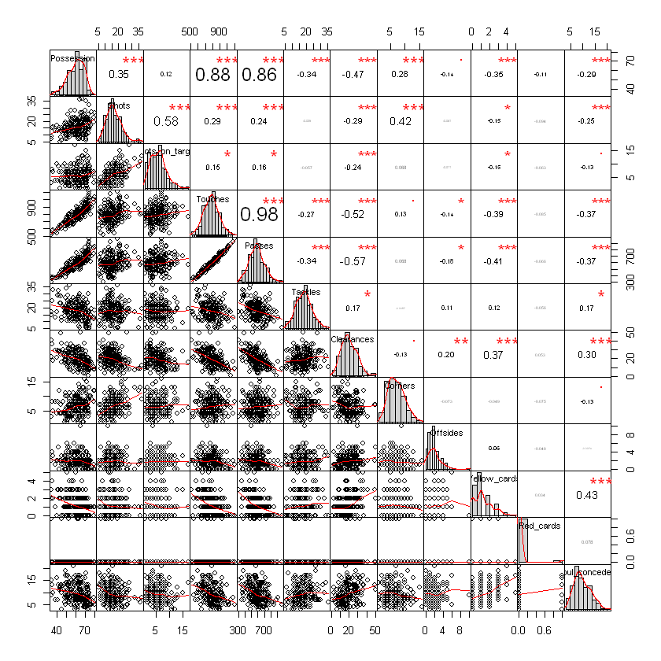

```r
# 리버풀
chart.Correlation(Liverpool_df, histogram=TRUE, pch=19)
```

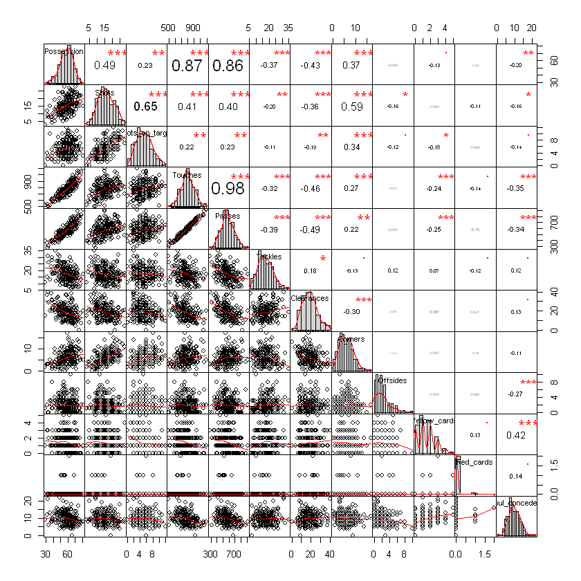

```r
# 첼시
chart.Correlation(Chelsea_df, histogram=TRUE, pch=19)
```

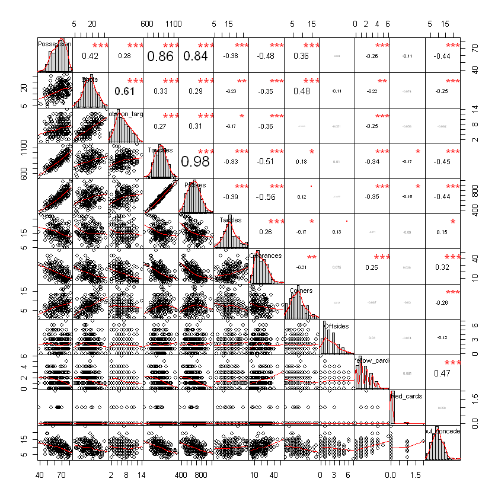

```r
# 맨시티
chart.Correlation(Mancity_df, histogram=TRUE, pch=19)
```

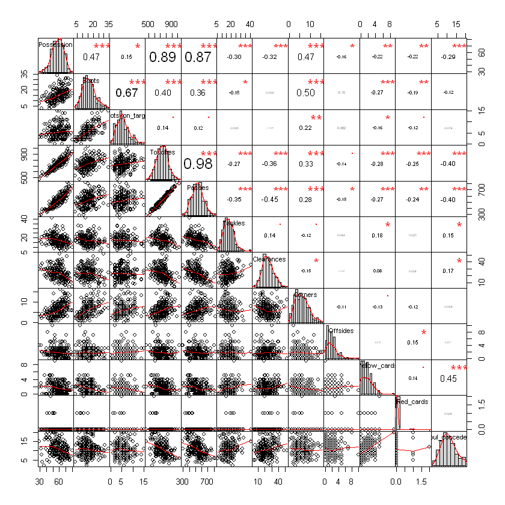

```r
# 토트넘
chart.Correlation(Tottenham_df, histogram=TRUE, pch=19)
```

## 상관관계 시각화2

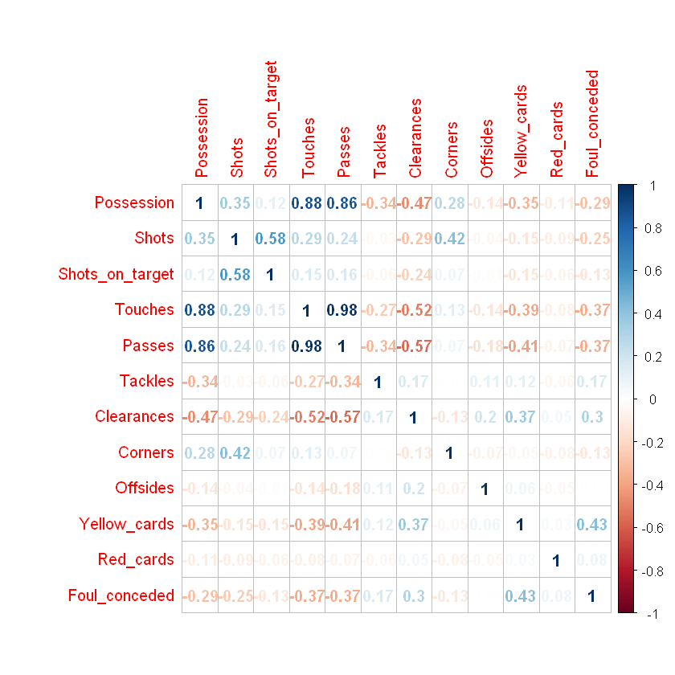

```r
# 리버풀
corrplot(Liverpool_cor, method="number")
```

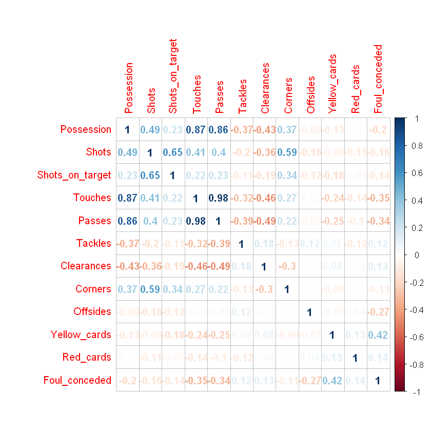

```r
# 첼시
corrplot(Chelsea_cor, method="number")
```

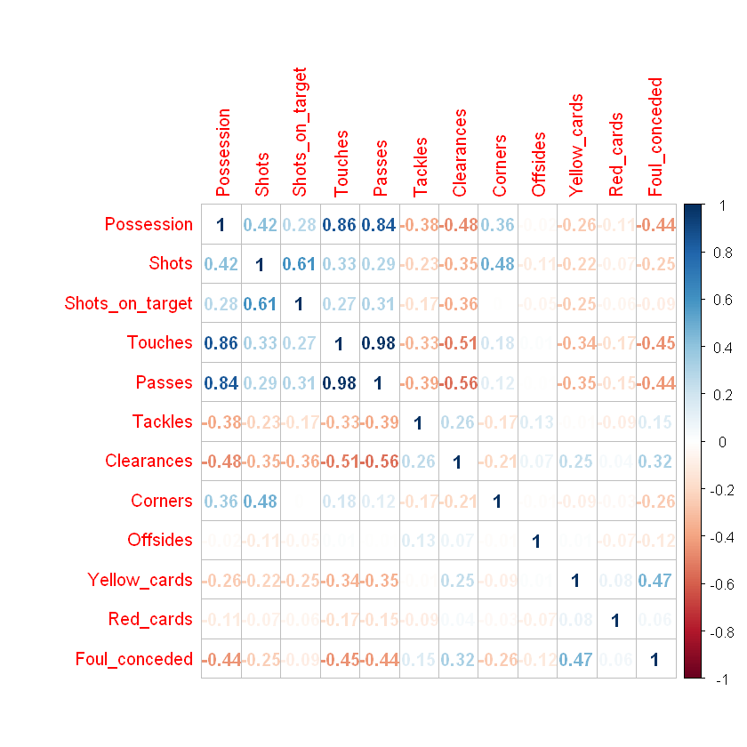

```r
# 맨시티
corrplot(Mancity_cor, method="number")
```

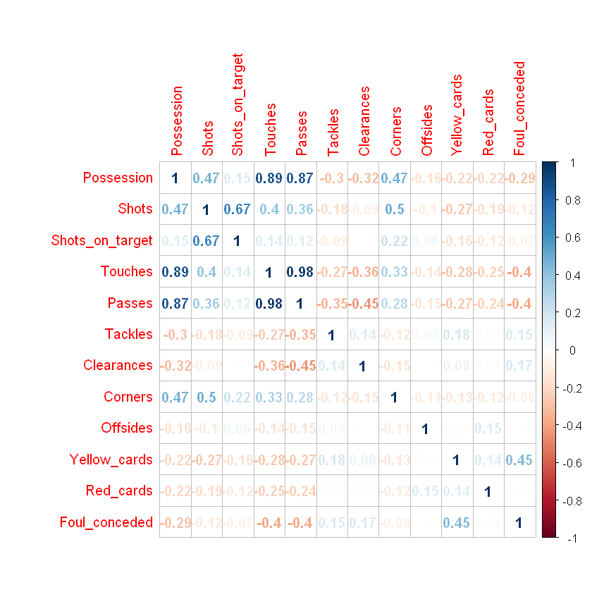

```r
# 토트넘
corrplot(Tottenham_cor, method="number")
```

## 상위 네 팀의 각 스텟별 상관 비교

```r
Possession_df <- cbind(cor(Liverpool_df,Liverpool_df[1]),cor(Chelsea_df,Chelsea_df[1]),
           cor(Mancity_df,Mancity_df[1]),cor(Tottenham_df,Tottenham_df[1]))

for (i in 1:4){
    for (j in 1:12){
        if (Possession_df[j,i]<=0.3 & Possession_df[j,i]>= -0.3){
            Possession_df[j,i] <- NA
        }
    }
}
```

```r
# 점유율
Team_list <- c('Liverpool','Chelsea','Mancity','Tottenham')

print(Team_list)
Possession_df
```

```
[1] "Liverpool" "Chelsea"   "Mancity"   "Tottenham"
```

|  | Possession | Possession | Possession | Possession |
| --- | --- | --- | --- | --- |
| Possession | 1.0000000 | 1.0000000 | 1.0000000 | 1.0000000 |
| Shots | 0.3535120 | 0.4949226 | 0.4160106 | 0.4700833 |
| Shots_on_target | NA | NA | NA | NA |
| Touches | 0.8757337 | 0.8725708 | 0.8597839 | 0.8921923 |
| Passes | 0.8563095 | 0.8599673 | 0.8413191 | 0.8741882 |
| Tackles | -0.3412818 | -0.3738041 | -0.3806534 | NA |
| Clearances | -0.4740693 | -0.4307255 | -0.4791768 | -0.3198516 |
| Corners | NA | 0.3738925 | 0.3560379 | 0.4712652 |
| Offsides | NA | NA | NA | NA |
| Yellow_cards | -0.3455096 | NA | NA | NA |
| Red_cards | NA | NA | NA | NA |
| Foul_conceded | NA | NA | -0.4403445 | NA |

```r
# 슛
Shots_df <- cbind(cor(Liverpool_df,Liverpool_df[2]),cor(Chelsea_df,Chelsea_df[2]),
           cor(Mancity_df,Mancity_df[2]),cor(Tottenham_df,Tottenham_df[2]))
for (i in 1:4){
    for (j in 1:12){
        if (Shots_df[j,i]<=0.3 & Shots_df[j,i]>= -0.3){
            Shots_df[j,i] <- NA
        }
    }
}
```

```r
print(Team_list)
Shots_df
```

```
[1] "Liverpool" "Chelsea"   "Mancity"   "Tottenham"
```

|  | Shots | Shots | Shots | Shots |
| --- | --- | --- | --- | --- |
| Possession | 0.3535120 | 0.4949226 | 0.4160106 | 0.4700833 |
| Shots | 1.0000000 | 1.0000000 | 1.0000000 | 1.0000000 |
| Shots_on_target | 0.5777912 | 0.6465033 | 0.6073357 | 0.6747544 |
| Touches | NA | 0.4117151 | 0.3281288 | 0.4041719 |
| Passes | NA | 0.3971846 | NA | 0.3567036 |
| Tackles | NA | NA | NA | NA |
| Clearances | NA | -0.3610405 | -0.3540783 | NA |
| Corners | 0.4219166 | 0.5852533 | 0.4820847 | 0.5024481 |
| Offsides | NA | NA | NA | NA |
| Yellow_cards | NA | NA | NA | NA |
| Red_cards | NA | NA | NA | NA |
| Foul_conceded | NA | NA | NA | NA |

```r
# 유효슛
Shots_on_target_df <- cbind(cor(Liverpool_df,Liverpool_df[3]),cor(Chelsea_df,Chelsea_df[3]),
           cor(Mancity_df,Mancity_df[3]),cor(Tottenham_df,Tottenham_df[3]))
for (i in 1:4){
    for (j in 1:12){
        if (Shots_on_target_df[j,i]<=0.3 & Shots_on_target_df[j,i]>= -0.3){
            Shots_on_target_df[j,i] <- NA
        }
    }
}
```

```r
print(Team_list)
Shots_on_target_df
```

```
[1] "Liverpool" "Chelsea"   "Mancity"   "Tottenham"
```

|  | Shots_on_target | Shots_on_target | Shots_on_target | Shots_on_target |
| --- | --- | --- | --- | --- |
| Possession | NA | NA | NA | NA |
| Shots | 0.5777912 | 0.6465033 | 0.6073357 | 0.6747544 |
| Shots_on_target | 1.0000000 | 1.0000000 | 1.0000000 | 1.0000000 |
| Touches | NA | NA | NA | NA |
| Passes | NA | NA | 0.3060967 | NA |
| Tackles | NA | NA | NA | NA |
| Clearances | NA | NA | -0.3645767 | NA |
| Corners | NA | 0.3393024 | NA | NA |
| Offsides | NA | NA | NA | NA |
| Yellow_cards | NA | NA | NA | NA |
| Red_cards | NA | NA | NA | NA |
| Foul_conceded | NA | NA | NA | NA |

```r
# 터치
Touches_df <- cbind(cor(Liverpool_df,Liverpool_df[4]),cor(Chelsea_df,Chelsea_df[4]),
           cor(Mancity_df,Mancity_df[4]),cor(Tottenham_df,Tottenham_df[4]))
for (i in 1:4){
    for (j in 1:12){
        if (Touches_df[j,i]<=0.3 & Touches_df[j,i]>= -0.3){
            Touches_df[j,i] <- NA
        }
    }
}
```

```r
print(Team_list)
Touches_df
```

```
[1] "Liverpool" "Chelsea"   "Mancity"   "Tottenham"
```

|  | Touches | Touches | Touches | Touches |
| --- | --- | --- | --- | --- |
| Possession | 0.8757337 | 0.8725708 | 0.8597839 | 0.8921923 |
| Shots | NA | 0.4117151 | 0.3281288 | 0.4041719 |
| Shots_on_target | NA | NA | NA | NA |
| Touches | 1.0000000 | 1.0000000 | 1.0000000 | 1.0000000 |
| Passes | 0.9838073 | 0.9827544 | 0.9828349 | 0.9783942 |
| Tackles | NA | -0.3176054 | -0.3306412 | NA |
| Clearances | -0.5175531 | -0.4613678 | -0.5109502 | -0.3580203 |
| Corners | NA | NA | NA | 0.3261586 |
| Offsides | NA | NA | NA | NA |
| Yellow_cards | -0.3908527 | NA | -0.3444829 | NA |
| Red_cards | NA | NA | NA | NA |
| Foul_conceded | -0.3714722 | -0.3541987 | -0.4510011 | -0.3968943 |

```r
# 패스
Passes_df <- cbind(cor(Liverpool_df,Liverpool_df[5]),cor(Chelsea_df,Chelsea_df[5]),
           cor(Mancity_df,Mancity_df[5]),cor(Tottenham_df,Tottenham_df[5]))
for (i in 1:4){
    for (j in 1:12){
        if (Passes_df[j,i]<=0.3 & Passes_df[j,i]>= -0.3){
            Passes_df[j,i] <- NA
        }
    }
}
```

```r
print(Team_list)
Passes_df
```

```
[1] "Liverpool" "Chelsea"   "Mancity"   "Tottenham"
```

|  | Passes | Passes | Passes | Passes |
| --- | --- | --- | --- | --- |
| Possession | 0.8563095 | 0.8599673 | 0.8413191 | 0.8741882 |
| Shots | NA | 0.3971846 | NA | 0.3567036 |
| Shots_on_target | NA | NA | 0.3060967 | NA |
| Touches | 0.9838073 | 0.9827544 | 0.9828349 | 0.9783942 |
| Passes | 1.0000000 | 1.0000000 | 1.0000000 | 1.0000000 |
| Tackles | -0.3362326 | -0.3915058 | -0.3892715 | -0.3457589 |
| Clearances | -0.5729155 | -0.4883294 | -0.5595538 | -0.4468415 |
| Corners | NA | NA | NA | NA |
| Offsides | NA | NA | NA | NA |
| Yellow_cards | -0.4106521 | NA | -0.3516650 | NA |
| Red_cards | NA | NA | NA | NA |
| Foul_conceded | -0.3719503 | -0.3417852 | -0.4350884 | -0.3963530 |

```r
# 태클
Tackles_df <- cbind(cor(Liverpool_df,Liverpool_df[6]),cor(Chelsea_df,Chelsea_df[6]),
           cor(Mancity_df,Mancity_df[6]),cor(Tottenham_df,Tottenham_df[6]))
for (i in 1:4){
    for (j in 1:12){
        if (Tackles_df[j,i]<=0.3 & Tackles_df[j,i]>= -0.3){
            Tackles_df[j,i] <- NA
        }
    }
}
```

```r
print(Team_list)
Tackles_df
```

```
[1] "Liverpool" "Chelsea"   "Mancity"   "Tottenham"
```

|  | Tackles | Tackles | Tackles | Tackles |
| --- | --- | --- | --- | --- |
| Possession | -0.3412818 | -0.3738041 | -0.3806534 | NA |
| Shots | NA | NA | NA | NA |
| Shots_on_target | NA | NA | NA | NA |
| Touches | NA | -0.3176054 | -0.3306412 | NA |
| Passes | -0.3362326 | -0.3915058 | -0.3892715 | -0.3457589 |
| Tackles | 1.0000000 | 1.0000000 | 1.0000000 | 1.0000000 |
| Clearances | NA | NA | NA | NA |
| Corners | NA | NA | NA | NA |
| Offsides | NA | NA | NA | NA |
| Yellow_cards | NA | NA | NA | NA |
| Red_cards | NA | NA | NA | NA |
| Foul_conceded | NA | NA | NA | NA |

```r
# 클리어링
Clearances_df <- cbind(cor(Liverpool_df,Liverpool_df[7]),cor(Chelsea_df,Chelsea_df[7]),
           cor(Mancity_df,Mancity_df[7]),cor(Tottenham_df,Tottenham_df[7]))
for (i in 1:4){
    for (j in 1:12){
        if (Clearances_df[j,i]<=0.3 & Clearances_df[j,i]>= -0.3){
            Clearances_df[j,i] <- NA
        }
    }
}
```

```r
print(Team_list)
Clearances_df
```

```
[1] "Liverpool" "Chelsea"   "Mancity"   "Tottenham"
```

|  | Clearances | Clearances | Clearances | Clearances |
| --- | --- | --- | --- | --- |
| Possession | -0.4740693 | -0.4307255 | -0.4791768 | -0.3198516 |
| Shots | NA | -0.3610405 | -0.3540783 | NA |
| Shots_on_target | NA | NA | -0.3645767 | NA |
| Touches | -0.5175531 | -0.4613678 | -0.5109502 | -0.3580203 |
| Passes | -0.5729155 | -0.4883294 | -0.5595538 | -0.4468415 |
| Tackles | NA | NA | NA | NA |
| Clearances | 1.0000000 | 1.0000000 | 1.0000000 | 1.0000000 |
| Corners | NA | NA | NA | NA |
| Offsides | NA | NA | NA | NA |
| Yellow_cards | 0.3710707 | NA | NA | NA |
| Red_cards | NA | NA | NA | NA |
| Foul_conceded | 0.3041127 | NA | 0.3240286 | NA |

```r
# 코너킥
Corners_df <- cbind(cor(Liverpool_df,Liverpool_df[8]),cor(Chelsea_df,Chelsea_df[8]),
           cor(Mancity_df,Mancity_df[8]),cor(Tottenham_df,Tottenham_df[8]))
for (i in 1:4){
    for (j in 1:12){
        if (Corners_df[j,i]<=0.3 & Corners_df[j,i]>= -0.3){
            Corners_df[j,i] <- NA
        }
    }
}
```

```r
print(Team_list)
Corners_df
```

```
[1] "Liverpool" "Chelsea"   "Mancity"   "Tottenham"
```

|  | Corners | Corners | Corners | Corners |
| --- | --- | --- | --- | --- |
| Possession | NA | 0.3738925 | 0.3560379 | 0.4712652 |
| Shots | 0.4219166 | 0.5852533 | 0.4820847 | 0.5024481 |
| Shots_on_target | NA | 0.3393024 | NA | NA |
| Touches | NA | NA | NA | 0.3261586 |
| Passes | NA | NA | NA | NA |
| Tackles | NA | NA | NA | NA |
| Clearances | NA | NA | NA | NA |
| Corners | 1.0000000 | 1.0000000 | 1.0000000 | 1.0000000 |
| Offsides | NA | NA | NA | NA |
| Yellow_cards | NA | NA | NA | NA |
| Red_cards | NA | NA | NA | NA |
| Foul_conceded | NA | NA | NA | NA |

```r
# 오프사이드
Offsides_df <- cbind(cor(Liverpool_df,Liverpool_df[9]),cor(Chelsea_df,Chelsea_df[9]),
           cor(Mancity_df,Mancity_df[9]),cor(Tottenham_df,Tottenham_df[9]))
for (i in 1:4){
    for (j in 1:12){
        if (Offsides_df[j,i]<=0.3 & Offsides_df[j,i]>= -0.3){
            Offsides_df[j,i] <- NA
        }
    }
}
```

```r
print(Team_list)
Offsides_df
```

```
[1] "Liverpool" "Chelsea"   "Mancity"   "Tottenham"
```

|  | Offsides | Offsides | Offsides | Offsides |
| --- | --- | --- | --- | --- |
| Possession | NA | NA | NA | NA |
| Shots | NA | NA | NA | NA |
| Shots_on_target | NA | NA | NA | NA |
| Touches | NA | NA | NA | NA |
| Passes | NA | NA | NA | NA |
| Tackles | NA | NA | NA | NA |
| Clearances | NA | NA | NA | NA |
| Corners | NA | NA | NA | NA |
| Offsides | 1 | 1 | 1 | 1 |
| Yellow_cards | NA | NA | NA | NA |
| Red_cards | NA | NA | NA | NA |
| Foul_conceded | NA | NA | NA | NA |

```r
# 옐로카드
Yellow_cards_df <- cbind(cor(Liverpool_df,Liverpool_df[10]),cor(Chelsea_df,Chelsea_df[10]),
           cor(Mancity_df,Mancity_df[10]),cor(Tottenham_df,Tottenham_df[10]))
for (i in 1:4){
    for (j in 1:12){
        if (Yellow_cards_df[j,i]<=0.3 & Yellow_cards_df[j,i]>= -0.3){
            Yellow_cards_df[j,i] <- NA
        }
    }
}
```

```r
print(Team_list)
Yellow_cards_df
```

```
[1] "Liverpool" "Chelsea"   "Mancity"   "Tottenham"
```

|  | Yellow_cards | Yellow_cards | Yellow_cards | Yellow_cards |
| --- | --- | --- | --- | --- |
| Possession | -0.3455096 | NA | NA | NA |
| Shots | NA | NA | NA | NA |
| Shots_on_target | NA | NA | NA | NA |
| Touches | -0.3908527 | NA | -0.3444829 | NA |
| Passes | -0.4106521 | NA | -0.3516650 | NA |
| Tackles | NA | NA | NA | NA |
| Clearances | 0.3710707 | NA | NA | NA |
| Corners | NA | NA | NA | NA |
| Offsides | NA | NA | NA | NA |
| Yellow_cards | 1.0000000 | 1.0000000 | 1.0000000 | 1.0000000 |
| Red_cards | NA | NA | NA | NA |
| Foul_conceded | 0.4284490 | 0.4197355 | 0.4682275 | 0.4463795 |

```r
# 레드카드
Red_cards_df <- cbind(cor(Liverpool_df,Liverpool_df[11]),cor(Chelsea_df,Chelsea_df[11]),
           cor(Mancity_df,Mancity_df[11]),cor(Tottenham_df,Tottenham_df[11]))
for (i in 1:4){
    for (j in 1:12){
        if (Red_cards_df[j,i]<=0.3 & Red_cards_df[j,i]>= -0.3){
            Red_cards_df[j,i] <- NA
        }
    }
}
```

```r
print(Team_list)
Red_cards_df
```

```
[1] "Liverpool" "Chelsea"   "Mancity"   "Tottenham"
```

|  | Red_cards | Red_cards | Red_cards | Red_cards |
| --- | --- | --- | --- | --- |
| Possession | NA | NA | NA | NA |
| Shots | NA | NA | NA | NA |
| Shots_on_target | NA | NA | NA | NA |
| Touches | NA | NA | NA | NA |
| Passes | NA | NA | NA | NA |
| Tackles | NA | NA | NA | NA |
| Clearances | NA | NA | NA | NA |
| Corners | NA | NA | NA | NA |
| Offsides | NA | NA | NA | NA |
| Yellow_cards | NA | NA | NA | NA |
| Red_cards | 1 | 1 | 1 | 1 |
| Foul_conceded | NA | NA | NA | NA |

```r
# 파울
Foul_conceded_df <- cbind(cor(Liverpool_df,Liverpool_df[12]),cor(Chelsea_df,Chelsea_df[12]),
           cor(Mancity_df,Mancity_df[12]),cor(Tottenham_df,Tottenham_df[12]))
for (i in 1:4){
    for (j in 1:12){
        if (Foul_conceded_df[j,i]<=0.3 & Foul_conceded_df[j,i]>= -0.3){
            Foul_conceded_df[j,i] <- NA
        }
    }
}
```

```r
print(Team_list)
Foul_conceded_df
```

```
[1] "Liverpool" "Chelsea"   "Mancity"   "Tottenham"
```

|  | Foul_conceded | Foul_conceded | Foul_conceded | Foul_conceded |
| --- | --- | --- | --- | --- |
| Possession | NA | NA | -0.4403445 | NA |
| Shots | NA | NA | NA | NA |
| Shots_on_target | NA | NA | NA | NA |
| Touches | -0.3714722 | -0.3541987 | -0.4510011 | -0.3968943 |
| Passes | -0.3719503 | -0.3417852 | -0.4350884 | -0.3963530 |
| Tackles | NA | NA | NA | NA |
| Clearances | 0.3041127 | NA | 0.3240286 | NA |
| Corners | NA | NA | NA | NA |
| Offsides | NA | NA | NA | NA |
| Yellow_cards | 0.4284490 | 0.4197355 | 0.4682275 | 0.4463795 |
| Red_cards | NA | NA | NA | NA |
| Foul_conceded | 1.0000000 | 1.0000000 | 1.0000000 | 1.0000000 |

## 결과

절대값 0.7 이상의 높은 상관을 가지는 변수는 네 팀 모두 아래와 같이 동일하게 났다.

- 점유율과 패스
- 점유율과 터치
- 패스와 터치

절대값 0.3 이상의 상관을 가지는 변수는 네 팀 모두 거의 유사했으나 아래와 같이 팀별로 차이가 존재함을 확인할 수 있다.

- 리버풀의 경우 점유율과 코너킥은 상관이 발견되지 않았지만 나머지 세 팀에서는 상관이 있음을 발견
- 첼시의 경우 코너킥과 유효슛의 경우 상관이 발견되지만 나머지 세 팀에서는 상관이 없음을 발견
- 이를 포함하여 각 차이가 존재하는 변수쌍 총 16개 발견

## 세부 분석

하지만 다른 팀과 달리 상관을 보이거나, 보이지 않는 등 다른 양상의 관계를 보여주는 스텟 또한 존재한다.

- 태클 점유율
- 코너킥 점유율
- 옐로카드 점유율
- 파울 점유율
- 슛 터치
- 슛 패스
- 슛 클리어링
- 유효슛 패스
- 유효슛 클리어링
- 유효슛 코너킥
- 터치 태클
- 터치 코너킥
- 터치 옐로카드
- 패스 옐로카드
- 클리어링 옐로
- 클리어링 파울

## 최근 다섯 시즌 전체 경기에서의 변수별 상관과 비교

### 1. 각 네 팀 모두 전체 경기를 분석한 것과 같이 절대값 0.7 이상의 높은 상관을 보이는 변수는 똑같았다.

- 점유율 - 패스
- 점유율 - 터치
- 패스와 - 터치

즉, 위 세 변수 관계들은 최근 프리미어 경기 내에서 가장 높은 상관을 지녔다고 할 수 있다.

### 2. 각 네 팀과 전체 경기 분석에서 0.3 이상의 상관을 똑같이 보여주는 변수 관계는 아래와 같다.

- 점유율 - 슛
- 점유율 - 클리어링
- 슛 - 유효슛
- 슛 - 코너킥
- 터치 - 클리어링
- 패스 - 클리어링
- 옐로카드 - 파울

즉, 위 변수 관계들은 최근 프리미어 경기 내에서 유의미한 상관을 지녔다고 할 수 있다.

### 3. 전체 경기에서는 상관이 있지만 네 팀에서는 상관이 없거나, 전체 경기에서는 상관이 없지만 네 팀에서는 상관이 있는 변수들이 존재하며, 이는 변수간 상관이 각 팀 별로 다를 수 있음을 의미한다.

## 정리

#### 1. 최근 프리미어 경기 내에서 아래 변수관계들은 항상 유의미한 상관을 보여줌을 확인할 수 있다.

```
점유율 - 패스, 점유율 - 터치, 패스와 - 터치, 점유율 - 슛, 점유율 - 클리어링, 슛 - 유효슛, 슛 - 코너킥, 터치 - 클리어링, 패스 - 클리어링, 옐로카드 - 파울
```

#### 2. 그 외 변수관계들은 각 팀에따라 상관이 있거나 없는 등 다른 양상을 보이기 때문에 모든 경기를 상관분석한 결과를 단순히 참고하기보다, 한 팀을 자세히 분석하는 것이 해당 팀의 스텟 간 상관을 이해하는 것에 큰 도움이 될 것이다.